# Estudis d'Informàtica, Multimedia i Telecomunicacions

# Mineria de dades: PAC1

Autor: Arnau Garcia Rodríguez

Octubre 2023

# 1 Exemple guiat

No es tracta d’una pauta per a repetir sinó diferents exemples per donar-vos idees i inspirar-vos en la resolució.

## 1.1 Descripció de l’origen del conjunt de dades

S’ha seleccionat un conjunt de dades del [National Highway Traffic Safety Administration](https://www.nhtsa.gov/) . El sistema d’informes d’anàlisi de mortalitat va ser creat als Estats Units per la National Highway Traffic Safety Administration per proporcionar una mesura global de la seguretat a les carreteres. (Font Wikipedia). Les dades pertany a l’any 2020. És tracta d’un conjunt de registres d’accidents que recullen dades significatives que els descriuen. Tots els accidents tenen alguna víctima mortal com a mínim. L’objectiu analític que tenim en ment és entendre que fa que un accident sigui greu i que vol dir que sigui greu. https://www.nhtsa.gov/crash-data-systems/fatality-analysis-reporting-system

## 1.2 Anàlisi exploratòria

Volem fer una primera aproximació al conjunt de dades trobat i respondre a les preguntes més bàsiques. Quant registres té? Quantes variables? De quina tipologia són? Com es distribueixen els valors de les variables? Hi ha problemes amb les dades, per exemple camps buits? Puc intuir ja el valor analític de les dades? Quines primeres conclusions puc extreure?

El primer pas per realitzar un anàlisi exploratòria és carregar el fitxer de dades.

```r
path = 'accident.CSV'
accidentData <- read.csv(path, row.names=NULL)
```

### 1.2.1 Exploració del conjunt de dades

Verifiquem l’estructura del joc de dades principal. Veiem el nombre de columnes que tenim i exemples dels continguts de les files.

```r
structure = str(accidentData)
```

```
## 'data.frame':    35766 obs. of  81 variables:
##  $ STATE       : int  1 1 1 1 1 1 1 1 1 1 ...
##  $ STATENAME   : chr  "Alabama" "Alabama" "Alabama" "Alabama" ...
##  $ ST_CASE     : int  10001 10002 10003 10004 10005 10006 10007 10008 10009 10010 ...
##  $ VE_TOTAL    : int  1 4 2 1 1 2 1 2 2 2 ...
##  $ VE_FORMS    : int  1 4 2 1 1 2 1 2 2 2 ...
##  $ PVH_INVL    : int  0 0 0 0 0 0 0 0 0 0 ...
##  $ PEDS        : int  0 0 0 0 0 0 1 0 0 0 ...
##  $ PERSONS     : int  4 6 2 5 1 3 1 2 4 3 ...
##  $ PERMVIT     : int  4 6 2 5 1 3 1 2 4 3 ...
##  $ PERNOTMVIT  : int  0 0 0 0 0 0 1 0 0 0 ...
##  $ COUNTY      : int  51 73 117 15 37 103 73 25 45 95 ...
##  $ COUNTYNAME  : chr  "ELMORE (51)" "JEFFERSON (73)" "SHELBY (117)" "CALHOUN (15)" ...
##  $ CITY        : int  0 350 0 0 0 0 330 0 0 1500 ...
##  $ CITYNAME    : chr  "NOT APPLICABLE" "BIRMINGHAM" "NOT APPLICABLE" "NOT APPLICABLE" ...
```

[output cut: 67 more lines]

Veiem que tenim **81** variables i **35.766** registres

Revisem la descripció de les variables contingudes al fitxer i els tipus de variables es correspon al que hem carregat. Les organitzem lògicament per donar-los sentit i construïm un petit diccionari de dades utilitzant la documentació auxiliar.

- **ST_CASE** identificador d’accident

**FETS A ESTUDIAR**

- **FATALS** morts
- **DRUNK_DR** conductors beguts
- **VE_TOTAL** nombre de vehicles implicats en total
- **VE_FORMS** nombre de vehicles en moviment implicats
- **PVH_INVL** nombre de vehicles estacionats implicats
- **PEDS** nombre de vianants implicats
- **PERSONS** nombre ocupants de vehicle implicats
- **PERMVIT** nombre conductors i ocupants implicats
- **PERNOTMVIT** nombre vianants, ciclistes, a cavall… qualsevol cosa menys vehicle motoritzat

**DIMENSIÓ GEOGRÀFICA**

- **STATE** codificació d’estat
- **STATENAME** nom d’estat
- **COUNTY** identificador de contat
- **COUNTYNAME** comtat
- **CITY** identificador de ciutat
- **CITYNAME** ciutat
- **NHS** 1 ha passat a autopista del NHS 0 no
- **NHSNAME** TBD
- **ROUTE** identificador de ruta
- **ROUTENAME** ruta
- **TWAY_ID** via de transit (1982)
- **TWAY_ID2** via de transit (2004)
- **RUR_URB** identificador de segment rural o urbà
- **RUR_URBNAME** segment rural o urbà
- **FUNC_SYS** classificació funcional segment
- **FUNC_SYSNAME** TBD
- **RD_OWNER** identificador propietari del segment
- **RD_OWNERNAME** propietari del segment
- **MILEPT** milla int
- **MILEPTNAME** milla chr
- **LATITUDE** latitud int
- **LATITUDENAME** latitud chr
- **LONGITUD** longitud int
- **LONGITUDNAME** longitud chr
- **SP_JUR** codi jurisdicció
- **SP_JURNAME** jurisdicció

**DIMENSIÓ TEMPORAL**

- **DAY** dia
- **DAYNAME** dia repetit
- **MONTH** mes
- **MONTHNAME** nom de mes
- **YEAR** any
- **DAY_WEEK** dia de la setmana
- **DAY_WEEKNAME** nom de dia de la setmana
- **HOUR** hora
- **HOURNAME** franja hora
- **MINUTE** minut int
- **MINUTENAME** minut chr

**DIMENSIÓ CONDICIONS ACCIDENT**

- **HARM_EV** codi primer esdeveniment de l’accident que produeixi danys o lesions
- **HARM_EVNAME** primer esdeveniment de l’accident que produeixi danys o lesions
- **MAN_COLL** codi de posició dels vehicles
- **MAN_COLLNAME** posició dels vehicles
- **RELJCT1** codi si hi ha àrea d’intercanvi
- **RELJCT1NAME** si hi ha àrea d’intercanvi
- **RELJCT2** codi proximitat encreuament
- **RELJCT2NAME** proximitat encreuament
- **TYP_INT** codi tipus d’intersecció
- **TYP_INTNAME** tipus d’intersecció
- **WRK_ZONE** codi tipologia d’obres
- **WRK_ZONENAME** tipologia d’obres
- **REL_ROAD** codi ubicació vehicle a la via
- **REL_ROADNAME** ubicació vehicle a la via
- **LGT_COND** codi condició lumínica
- **LGT_CONDNAME** condició lumínica

**DIMENSIÓ METEOROLOGIA**

- **WEATHER** codi temps
- **WEATHERNAME** : temps

**ALTRES**

- **SCH_BUS** codi si vehicle escolar implicat
- **SCH_BUSNAME** vehicle escolar implicat
- **RAIL** codi si dins o a prop pas ferroviari
- **RAILNAME** si dins o a prop pas ferroviari

**DIMENSIÓ SERVEI EMERGENCIES**

- **NOT_HOUR** hora notificació a emergències int
- **NOT_HOURNAME** hora notificació a emergències franja
- **NOT_MIN** minut notificació a emergències int
- **NOT_MINNAME** minut notificació a emergències chr
- **ARR_HOUR** hora arribada emergències int
- **ARR_HOURNAME** hora arribada emergències franja
- **ARR_MIN** minut arribada emergències int
- **ARR_MINNAME** minut arribada emergències franja
- **HOSP_HR** hora arribada hospital int
- **HOSP_HRNAME** hora arribada hospital franja
- **HOSP_MN** minut arribada hospital int
- **HOSP_MNNAME** : minut arribada hospital franja

## 1.3 Preprocessament i gestió de característiques

### 1.3.1 Neteja

El següent pas serà la neteja de dades, mirant si hi ha valors buits o nulls.

```r
print('NA')
```

```
## [1] "NA"
```

```r
colSums(is.na(accidentData))
```

```
##        STATE    STATENAME      ST_CASE     VE_TOTAL     VE_FORMS     PVH_INVL
##            0            0            0            0            0            0
##         PEDS      PERSONS      PERMVIT   PERNOTMVIT       COUNTY   COUNTYNAME
##            0            0            0            0            0            0
##         CITY     CITYNAME          DAY      DAYNAME        MONTH    MONTHNAME
##            0            0            0            0            0            0
##         YEAR     DAY_WEEK DAY_WEEKNAME         HOUR     HOURNAME       MINUTE
##            0            0            0            0            0            0
##   MINUTENAME          NHS      NHSNAME        ROUTE    ROUTENAME      TWAY_ID
##            0            0            0            0            0            0
##     TWAY_ID2      RUR_URB  RUR_URBNAME     FUNC_SYS FUNC_SYSNAME     RD_OWNER
##            0            0            0            0            0            0
## RD_OWNERNAME       MILEPT   MILEPTNAME     LATITUDE LATITUDENAME     LONGITUD
##            0            0            0            0            0            0
## LONGITUDNAME       SP_JUR   SP_JURNAME      HARM_EV  HARM_EVNAME     MAN_COLL
##            0            0            0            0            0            0
## MAN_COLLNAME      RELJCT1  RELJCT1NAME      RELJCT2  RELJCT2NAME      TYP_INT
##            0            0            0            0            0            0
##  TYP_INTNAME     WRK_ZONE WRK_ZONENAME     REL_ROAD REL_ROADNAME     LGT_COND
##            0            0            0            0            0            0
## LGT_CONDNAME      WEATHER  WEATHERNAME      SCH_BUS  SCH_BUSNAME         RAIL
##            0            0            0            0            0            0
##     RAILNAME     NOT_HOUR NOT_HOURNAME      NOT_MIN  NOT_MINNAME     ARR_HOUR
##            0            0            0            0            0            0
## ARR_HOURNAME      ARR_MIN  ARR_MINNAME      HOSP_HR  HOSP_HRNAME      HOSP_MN
##            0            0            0            0            0            0
##  HOSP_MNNAME       FATALS     DRUNK_DR
##            0            0            0
```

```r
print('Blancs')
```

```
## [1] "Blancs"
```

```r
colSums(accidentData=="")
```

```
##        STATE    STATENAME      ST_CASE     VE_TOTAL     VE_FORMS     PVH_INVL
##            0            0            0            0            0            0
##         PEDS      PERSONS      PERMVIT   PERNOTMVIT       COUNTY   COUNTYNAME
##            0            0            0            0            0            0
##         CITY     CITYNAME          DAY      DAYNAME        MONTH    MONTHNAME
##            0            0            0            0            0            0
##         YEAR     DAY_WEEK DAY_WEEKNAME         HOUR     HOURNAME       MINUTE
##            0            0            0            0            0            0
##   MINUTENAME          NHS      NHSNAME        ROUTE    ROUTENAME      TWAY_ID
##            0            0            0            0            0            0
##     TWAY_ID2      RUR_URB  RUR_URBNAME     FUNC_SYS FUNC_SYSNAME     RD_OWNER
##        26997            0            0            0            0            0
## RD_OWNERNAME       MILEPT   MILEPTNAME     LATITUDE LATITUDENAME     LONGITUD
##            0            0            0            0            0            0
## LONGITUDNAME       SP_JUR   SP_JURNAME      HARM_EV  HARM_EVNAME     MAN_COLL
##            0            0            0            0            0            0
## MAN_COLLNAME      RELJCT1  RELJCT1NAME      RELJCT2  RELJCT2NAME      TYP_INT
##            0            0            0            0            0            0
##  TYP_INTNAME     WRK_ZONE WRK_ZONENAME     REL_ROAD REL_ROADNAME     LGT_COND
##            0            0            0            0            0            0
## LGT_CONDNAME      WEATHER  WEATHERNAME      SCH_BUS  SCH_BUSNAME         RAIL
##            0            0            0            0            0            0
##     RAILNAME     NOT_HOUR NOT_HOURNAME      NOT_MIN  NOT_MINNAME     ARR_HOUR
##            0            0            0            0            0            0
## ARR_HOURNAME      ARR_MIN  ARR_MINNAME      HOSP_HR  HOSP_HRNAME      HOSP_MN
##            0            0            0            0            0            0
##  HOSP_MNNAME       FATALS     DRUNK_DR
##            0            0            0
```

Veiem que no hi ha valors nuls a les dades. També verifiquem camps omplerts de espais en blanc. En aquest cas sí trobem el camp TWAY_ID2 amb 26.997 valors en blanc. Valorem no fer cap acció d’eliminar registres ja que aquest camp no l’utilitzarem.

Anem a crear histogrames i descriure els valors per veure les dades en general d’aquests atributs per fer una primera aproximació al contingut de les dades:

```r
if (!require('ggplot2')) install.packages('ggplot2'); library('ggplot2')
if(!require('Rmisc')) install.packages('Rmisc'); library('Rmisc')
if(!require('dplyr')) install.packages('dplyr'); library('dplyr')
if(!require('xfun')) install.packages('xfun'); library('xfun')

summary(accidentData[c("FATALS","DRUNK_DR")])
```

```
##      FATALS         DRUNK_DR
##  Min.   :1.000   Min.   :0.0000
##  1st Qu.:1.000   1st Qu.:0.0000
##  Median :1.000   Median :0.0000
##  Mean   :1.085   Mean   :0.2664
##  3rd Qu.:1.000   3rd Qu.:1.0000
##  Max.   :8.000   Max.   :4.0000
```

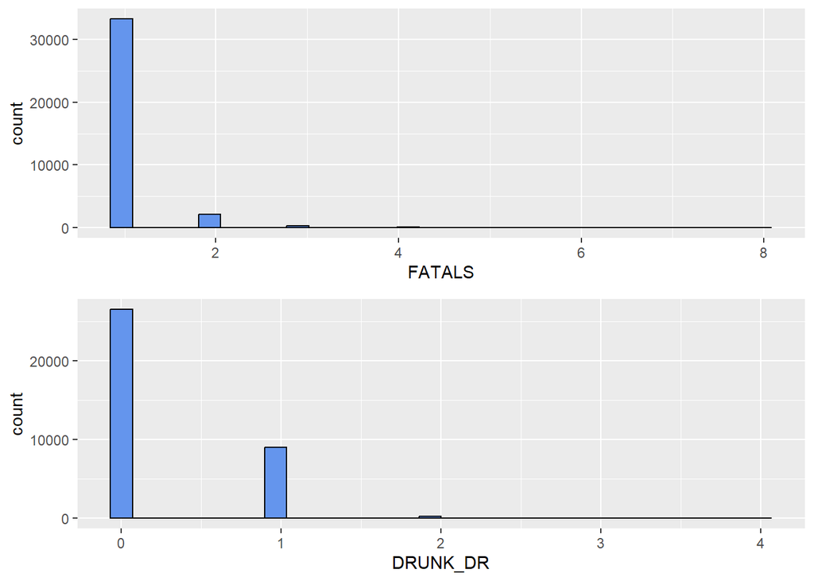

```r
#Crearem primer una llista per mostrar desprès les gràfiques en un sol grid
#Crearem una llista per mostrar els atributs que interessen.
histList<- list()

n = c("FATALS","DRUNK_DR")
accidentDataAux= accidentData %>% select(all_of(n))
for(i in 1:ncol(accidentDataAux)){
  col <- names(accidentDataAux)[i]
  ggp <- ggplot(accidentDataAux, aes_string(x = col)) +
    geom_histogram(bins = 30, fill = "cornflowerblue", color = "black",ggtittle = "Comptador d'ocurrències per variable")
      histList[[i]] <- ggp  # afegim cada plot a la llista buida
}
 multiplot(plotlist = histList, cols = 1)
```

Observacions:

Nombre de morts: Tots els accidents recollits en aquestes dades reporten una mort com a mínim. Sent l’accident més greu amb vuit víctimes i veiem que la distribució s’acumula de forma molt evident en una mort per accident.

```r
summary(accidentData[c("VE_TOTAL","VE_FORMS","PVH_INVL")])
```

```
##     VE_TOTAL        VE_FORMS         PVH_INVL
##  Min.   : 1.00   Min.   : 1.000   Min.   : 0.00000
##  1st Qu.: 1.00   1st Qu.: 1.000   1st Qu.: 0.00000
##  Median : 1.00   Median : 1.000   Median : 0.00000
##  Mean   : 1.56   Mean   : 1.517   Mean   : 0.04269
##  3rd Qu.: 2.00   3rd Qu.: 2.000   3rd Qu.: 0.00000
##  Max.   :15.00   Max.   :15.000   Max.   :10.00000
```

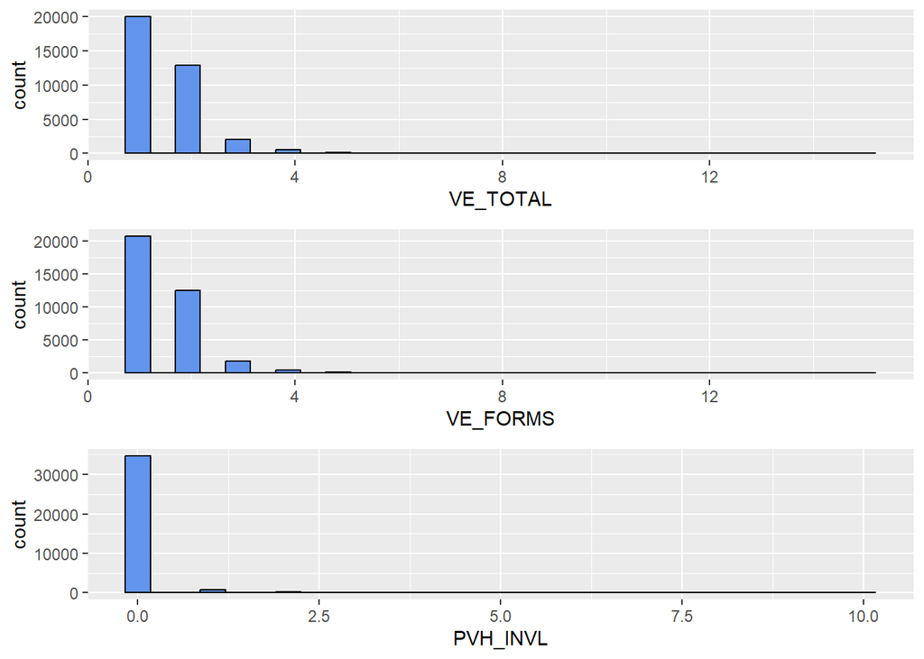

```r
#Crearem una llista per mostrar els atributs que interessen.
histList<- list()
n = c("VE_TOTAL","VE_FORMS","PVH_INVL")
accidentDataAux= accidentData %>% select(all_of(n))
for(i in 1:ncol(accidentDataAux)){
  col <- names(accidentDataAux)[i]
  ggp <- ggplot(accidentDataAux, aes_string(x = col)) +
    geom_histogram(bins = 30, fill = "cornflowerblue", color = "black")
      histList[[i]] <- ggp  # afegim cada plot a la llista buida
}
 multiplot(plotlist = histList, cols = 1)
```

Observacions pel que fa als vehicles implicats.

```r
summary(accidentData[c("PEDS","PERSONS","PERMVIT","PERNOTMVIT")])
```

```
##       PEDS           PERSONS          PERMVIT         PERNOTMVIT
##  Min.   :0.0000   Min.   : 0.000   Min.   : 0.000   Min.   :0.0000
##  1st Qu.:0.0000   1st Qu.: 1.000   1st Qu.: 1.000   1st Qu.:0.0000
##  Median :0.0000   Median : 2.000   Median : 2.000   Median :0.0000
##  Mean   :0.2285   Mean   : 2.173   Mean   : 2.163   Mean   :0.2387
##  3rd Qu.:0.0000   3rd Qu.: 3.000   3rd Qu.: 3.000   3rd Qu.:0.0000
##  Max.   :8.0000   Max.   :61.000   Max.   :61.000   Max.   :9.0000
```

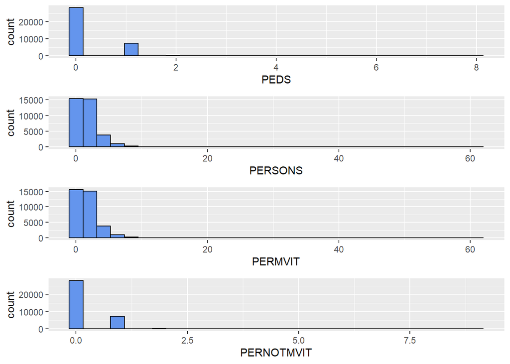

```r
#Crearem una llista per mostrar els atributs que interessen.
histList<- list()
n = c("PEDS","PERSONS","PERMVIT","PERNOTMVIT")
accidentDataAux= accidentData %>% select(all_of(n))
for(i in 1:ncol(accidentDataAux)){
  col <- names(accidentDataAux)[i]
  ggp <- ggplot(accidentDataAux, aes_string(x = col)) +
    geom_histogram(bins = 30, fill = "cornflowerblue", color = "black")
      histList[[i]] <- ggp  # afegim cada plot a la llista buida
}
 multiplot(plotlist = histList, cols = 1)
```

Observacions pel que fa a les persones implicades en un accident.

El nombre de vianant implicats (PEDS) és molt baix sent coherent amb el tipus de via que s’estudia i on no és habitual que hi hagi gent caminant. Amb tot el valor com a mitjana de 0,22 i màxim de 8 obliga a investigar més aquesta dada. (PERSONS) El nombre d’ocupants de vehicle implicats es situa com a mitjana en 2,1 (PERMVIT) El nombre conductors i ocupants de vehicles en circulació implicats amb valor de mitjana de 2,1. Aquestes dues variables recullen la mateixa informació però la quantifiquen de diferent manera. L’accident amb el major nombre d’ocupants és de 61 persones.  
Pel que nombre vianant, ciclistes, fins i tot persones en vehicles aparcats… qualsevol cosa menys vehicle circulant (PERNOTMVIT) veiem que augmenta una mica la mitjana respecte a vianant ja que entenen que s’inclouen més casos.

Anem a aprofundir una mica en el tema de la relació de l’alcohol en els conductors i el nombre d’accidents.

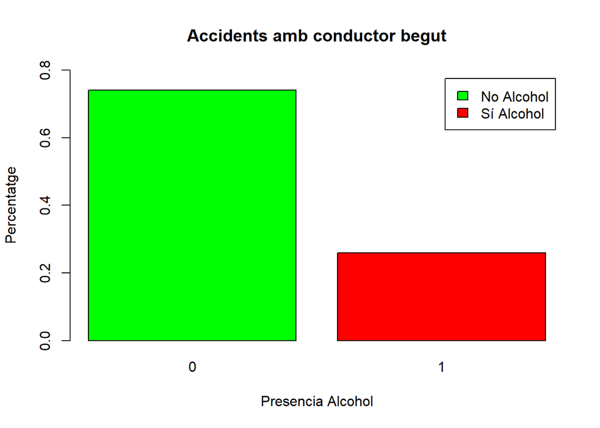

```r
accidentData$alcohol <- ifelse(accidentData$DRUNK_DR %in% c(0), 0, 1)
counts <- table(accidentData$alcohol)
barplot(prop.table(counts),col=c("green","red"), main="Accidents amb conductor begut", legend.text=c("No Alcohol","Sí Alcohol"),xlab ="Presencia Alcohol", ylab = "Percentatge",ylim=c(0,0.8) )
```

Observem ara com es distribueixen les morts per accident.

```r
df1 <- accidentData %>%
  group_by(accidentData$FATALS) %>%
  dplyr::summarise(counts = n())
df1
```

```
## # A tibble: 8 × 2
##   `accidentData$FATALS` counts
##                   <int>  <int>
## 1                     1  33226
## 2                     2   2154
## 3                     3    289
## 4                     4     71
## 5                     5     20
## 6                     6      4
## 7                     7      1
## 8                     8      1
```

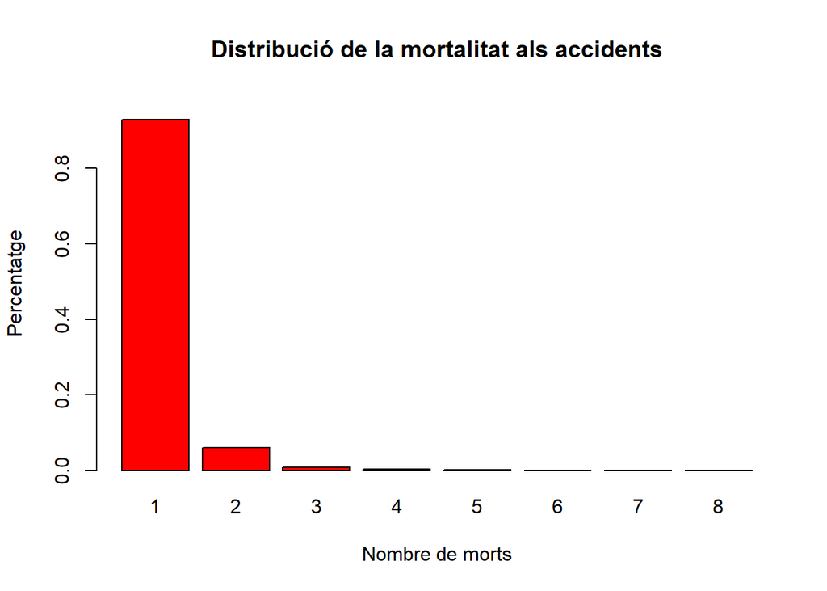

```r
counts <- table(accidentData$FATALS)
barplot(prop.table(counts),col=("red"),ylim=c(0,0.99),main="Distribució de la mortalitat als accidents",xlab ="Nombre de morts", ylab = "Percentatge")
```

Veiem que la majoria d’accidents tenen com a mínim un mort. Anem ara estudiar relacionat mortalitat alcohol.

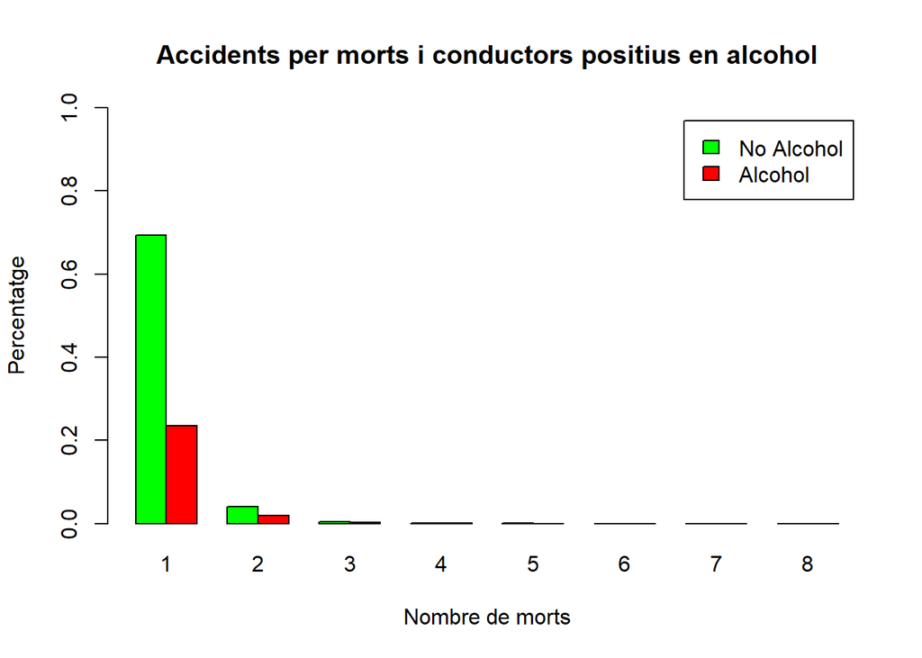

```r
counts <- table(accidentData$alcohol, accidentData$FATALS)
colors <- c("green", "red")
barplot(prop.table(counts), beside = TRUE, col = colors,
        ylim = c(0, 1), axes = TRUE,
        xlab = "Nombre de morts",
        ylab = "Percentatge",
        main = "Accidents per morts i conductors positius en alcohol",
        legend = c("No Alcohol", "Alcohol"),
        fill = colors)
```

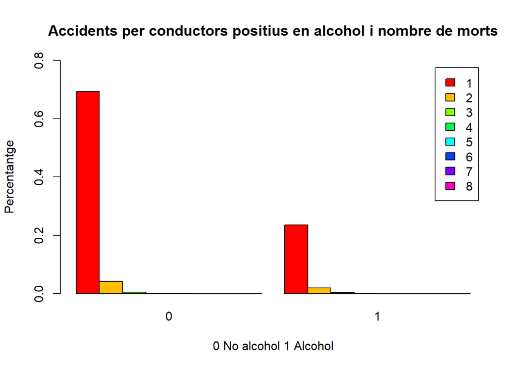

```r
counts <- table(accidentData$FATALS, accidentData$alcohol)
barplot(prop.table(counts), main="Accidents per conductors positius en alcohol i nombre de morts",
  xlab="0 No alcohol 1 Alcohol", col=rainbow(8), ylab="Percentantge",
  legend = rownames(counts), beside=TRUE,ylim=c(0,0.8))
```

Provarem ara si hi ha relació entre l’estat on ha passat l’accident i el nombre de conductors beguts. Fitrem els cinc estats on hi ha més accidents.

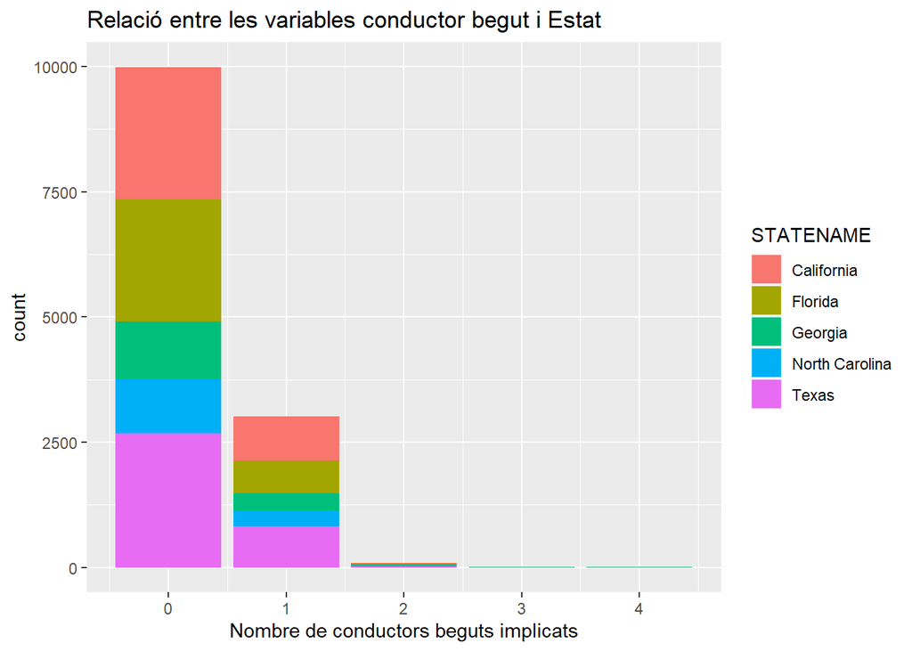

```r
accidentDataST5=subset(accidentData, accidentData$STATENAME == "California" | accidentData$STATENAME == "Texas" | accidentData$STATENAME == "Florida" | accidentData$STATENAME == "Georgia" | accidentData$STATENAME == "North Carolina")
files=dim(accidentDataST5)[1]
ggplot(data=accidentDataST5[1:files,],aes(x=DRUNK_DR,fill=STATENAME))+geom_bar()+ggtitle("Relació entre les variables conductor begut i Estat")+labs(x="Nombre de conductors beguts implicats")
```

Com a reflexió aquest gràfic té que passar pel filtre de percentuar el nombre d’accidents per estat i la població de l’estat per no treure conclusions precipitades.

Vegem ara com en un mateix gràfic de freqüències podem treballar amb 3 variables: FATALS, STATENAME i WEATHERNAME.

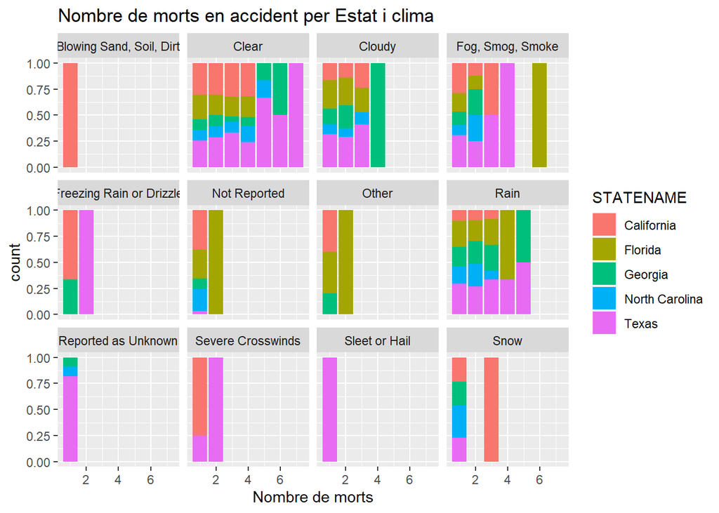

```r
ggplot(data = accidentDataST5[1:files,],aes(x=FATALS,fill=STATENAME))+geom_bar(position="fill")+facet_wrap(~WEATHERNAME)+ggtitle("Nombre de morts en accident per Estat i clima")+labs(x="Nombre de morts")
```

Aquesta gràfica està bé com a mecànica de construcció però els resultats els posem en dubte. Està bé com a pas inicial però cal aprofundir molt més.

Anem a cercar les correlacions en funció de les morts i unes variables triades que creiem poden ajudar a explicar l’augment de morts per accident:

**DRUNK_DR** conductors beguts **VE_TOTAL** nombre vehicles implicats en total **VE_FORMS** nombre vehicles en moviment implicats **PVH_INVL** nombre vehicles estacionats implicats **PEDS** nombre vianants implicats **PERSONS** nombre ocupants de vehicle implicats **PERMVIT** nombre conductors i ocupants implicats **PERNOTMVIT** nombre vianants, ciclistes… qualsevol cosa menys vehicle motoritzat

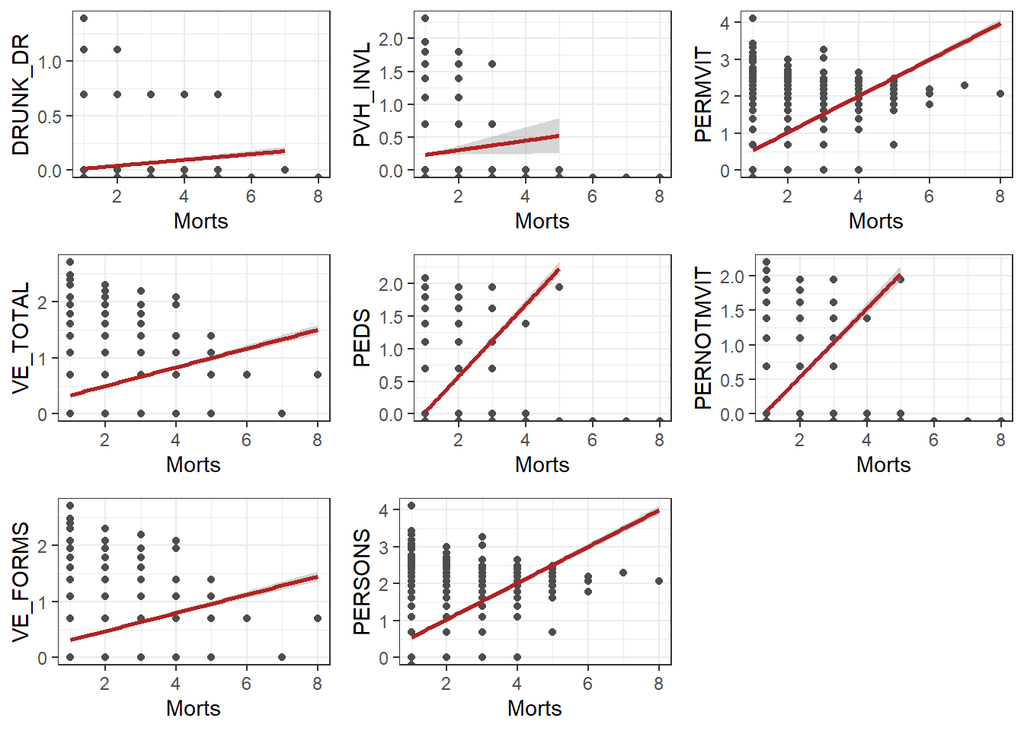

```r
# Utilitzem aquesta llibreria per fer servir la funcio multiplot()
if(!require('Rmisc')) install.packages('Rmisc'); library('Rmisc')
#Crearem primer una llista per mostrar les gràfiques de correlacions
#Crearem una llista per mostrar els atributs que interessen.


n = c("DRUNK_DR","VE_TOTAL","VE_FORMS","PVH_INVL","PEDS","PERSONS","PERMVIT","PERNOTMVIT")
accidentDataAux= accidentData %>% select(all_of(n))
histList2<- vector('list', ncol(accidentDataAux))
for(i in seq_along(accidentDataAux)){
  message(i)
histList2[[i]]<-local({
  i<-i
  col <-log(accidentDataAux[[i]])
  ggp<- ggplot(data = accidentDataAux, aes(x = accidentData$FATALS, y=col)) +
    geom_point(color = "gray30") + geom_smooth(method = lm,color = "firebrick") +
    theme_bw() + xlab("Morts") + ylab(names(accidentDataAux)[i])
  })

}
multiplot(plotlist = histList2, cols = 3)
```

Podem veure que:

Utilitzem les columnes que ens interessa per fer la matriu i la visualitzarem utilitzant la funció corrplot.

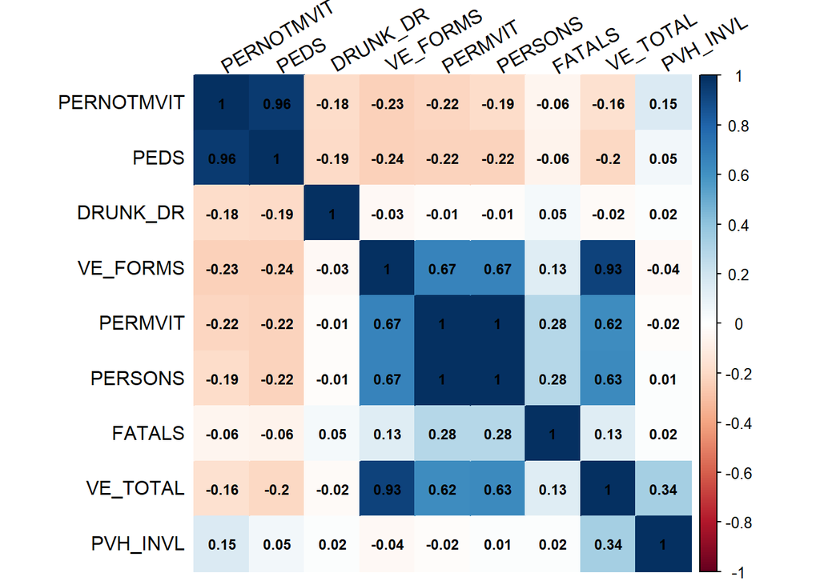

```r
# https://cran.r-project.org/web/packages/corrplot/vignettes/corrplot-intro.html
if(!require("corrplot")) install.packages("corrplot"); library("corrplot")
n = c("FATALS","DRUNK_DR","VE_TOTAL","VE_FORMS","PVH_INVL","PEDS","PERSONS","PERMVIT","PERNOTMVIT")
factors= accidentData %>% select(all_of(n))
res<-cor(factors)
corrplot(res,method="color",tl.col="black", tl.srt=30, order = "AOE",
   number.cex=0.75,sig.level = 0.01, addCoef.col = "black")
```

No veiem que hi hagi una correlació negativa significativa entre cap variable i sí una molt bona correlació ja previsible entre els vianants implicats i persones involucrades a l’accident que no van en cotxe. (PEDS i PERNOTMVIT) El mateix podem observar pel que fa al nombre de conductors i ocupants implicats (PERMVIT) i el nombre de vehicles implicats en moviment (VE_FORMS) o el total de vehicles (VE_TOTAL).

```r
if (!require('tidyverse')) install.packages('tidyverse'); library('tidyverse')
cor.test(x = accidentData$PERSONS, y = accidentData$FATALS, method = "kendall")
```

```
##
##  Kendall's rank correlation tau
##
## data:  accidentData$PERSONS and accidentData$FATALS
## z = 53.008, p-value < 2.2e-16
## alternative hypothesis: true tau is not equal to 0
## sample estimates:
##       tau
## 0.2558174
```

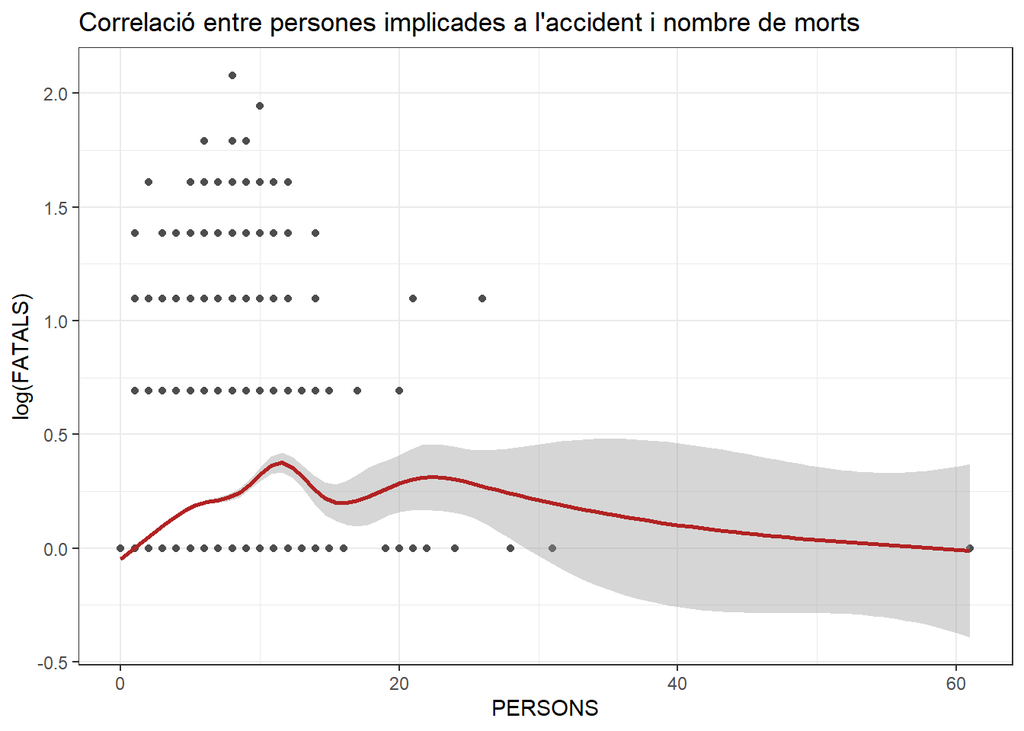

```r
ggplot(data = accidentData, aes(x = PERSONS, y = log(FATALS))) + geom_point(color = "gray30") + geom_smooth(color = "firebrick") + theme_bw() +ggtitle("Correlació entre persones implicades a l'accident i nombre de morts")
```

De l’observació d’aquest gràfic podem concloure que efectivament el nombre de morts augmenta en funció de les persones implicades en un accident però que la correlació no és tan elevada ni continua com es podia preveure.

## 1.4 Construcció de conjunt de dades final

Si dues variables estan tan altament correlacionades que òbviament impartiran gairebé exactament la mateixa informació en un model de regressió per exemple. Però, en incloure totes dues, en realitat estem debilitant el model. No estem afegint informació incremental. En lloc d’això, estem fent un model sorollós. No és una bona cosa.

Com hem vist abans tenim una correlació molt gran entre PEDS i PERNOTMVIT, per tant podríem eliminar la columna de vianants (PEDS) i deixar el total de vianants i altres reflectit a PERNOTMVIT.

```r
# accidentData$PEDS<- NULL
str(accidentData)
```

```
## 'data.frame':    35766 obs. of  82 variables:
##  $ STATE       : int  1 1 1 1 1 1 1 1 1 1 ...
##  $ STATENAME   : chr  "Alabama" "Alabama" "Alabama" "Alabama" ...
##  $ ST_CASE     : int  10001 10002 10003 10004 10005 10006 10007 10008 10009 10010 ...
##  $ VE_TOTAL    : int  1 4 2 1 1 2 1 2 2 2 ...
##  $ VE_FORMS    : int  1 4 2 1 1 2 1 2 2 2 ...
##  $ PVH_INVL    : int  0 0 0 0 0 0 0 0 0 0 ...
##  $ PEDS        : int  0 0 0 0 0 0 1 0 0 0 ...
##  $ PERSONS     : int  4 6 2 5 1 3 1 2 4 3 ...
##  $ PERMVIT     : int  4 6 2 5 1 3 1 2 4 3 ...
##  $ PERNOTMVIT  : int  0 0 0 0 0 0 1 0 0 0 ...
##  $ COUNTY      : int  51 73 117 15 37 103 73 25 45 95 ...
##  $ COUNTYNAME  : chr  "ELMORE (51)" "JEFFERSON (73)" "SHELBY (117)" "CALHOUN (15)" ...
##  $ CITY        : int  0 350 0 0 0 0 330 0 0 1500 ...
##  $ CITYNAME    : chr  "NOT APPLICABLE" "BIRMINGHAM" "NOT APPLICABLE" "NOT APPLICABLE" ...
```

[output cut: 68 more lines]

### 1.4.1 Codificació

Seguidament anem a assignar un 1 per accidents que es produeixen de matinada (01h a 06h a l’hivern) i un 0 per a la resta de franja horària, es a dir, anem a categoritzar la variable HOUR i així tindrem una variable numèrica que ens permetrà treballar millor en el futur, l’anomenarem matinada. Després l’utilitzarem per veure com es distribueixen els accidents en les dues franges horàries. Hem de tenir en compte que la hora inclou el codi 99 què vol dir que l’hora no està informada. Mirarem de filtrar els registres amb aquest valor per excloure’ls.

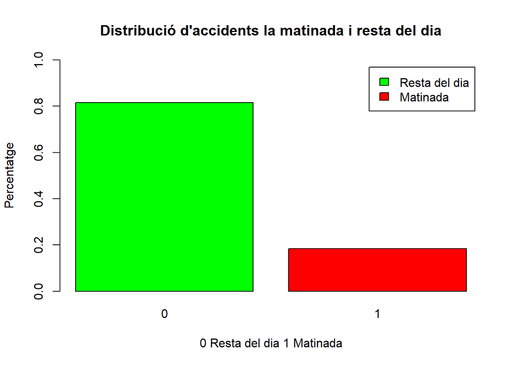

```r
accidentDataAux=subset(accidentData, accidentData$HOUR <= 24)

accidentData$matinada <- NA
accidentData$matinada[accidentDataAux$HOUR >=1 & accidentDataAux$HOUR <= 6] <- 1
accidentData$matinada[accidentDataAux$HOUR ==0 | accidentDataAux$HOUR >6 ] <- 0

counts <- table(accidentData$matinada)
barplot(prop.table(counts),col=c("green","red"),legend.text=c("Resta del dia","Matinada"),ylim=c(0,1), main="Distribució d'accidents la matinada i resta del dia",xlab="0 Resta del dia 1 Matinada",ylab="Percentatge" )
```

### 1.4.2 Discretització

```r
summary(accidentDataAux[,"HOUR"])
```

```
##    Min. 1st Qu.  Median    Mean 3rd Qu.    Max.
##    0.00    7.00   15.00   13.19   19.00   23.00
```

Discretitzem amb intervals. Els criteris de tall horaris estan agafats de la Web del Parlament de Catalunya.

```r
accidentDataAux["segment_horari"] <- cut(accidentDataAux$HOUR, breaks = c(0,4,11,14,18,22), labels = c("Matinada", "Matí", "Migdia", "Vespre","Nit"))
```

Observem les dades discretitzades i construïm un gràfic per analitzar com s’agrupen els accidents.

```r
head(accidentDataAux$segment_horari)
```

```
## [1] Matinada Vespre   Migdia   Vespre   <NA>     Vespre
## Levels: Matinada Matí Migdia Vespre Nit
```

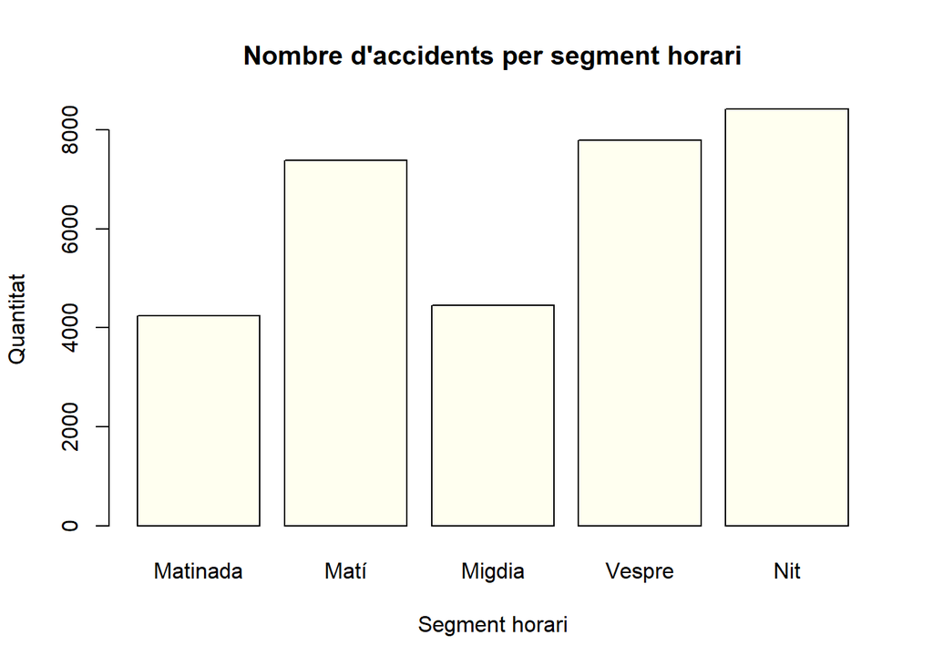

```r
plot(accidentDataAux$segment_horari,main="Nombre d'accidents per segment horari",xlab="Segment horari", ylab="Quantitat",col = "ivory")
```

Ara anem a discretitzar la variable que conté el nombre de vehicles implicats en un accident (VE_TOTALS) ja que era una de les que las distancies entre els seus valors era molt gran:

```r
# Farem servir funció discretize d'arules: This function implements several basic unsupervised methods to convert a continuous variable into a categorical variable (factor) using different binning strategies.
# https://cran.r-project.org/web/packages/arules/index.html
if (!require('arules')) install.packages('arules'); library('arules')
set.seed(2)
table(discretize(accidentData$VE_TOTAL, "cluster" ))
```

```
##
##    [1,1.57) [1.57,3.38)   [3.38,15]
##       19972       14972         822
```

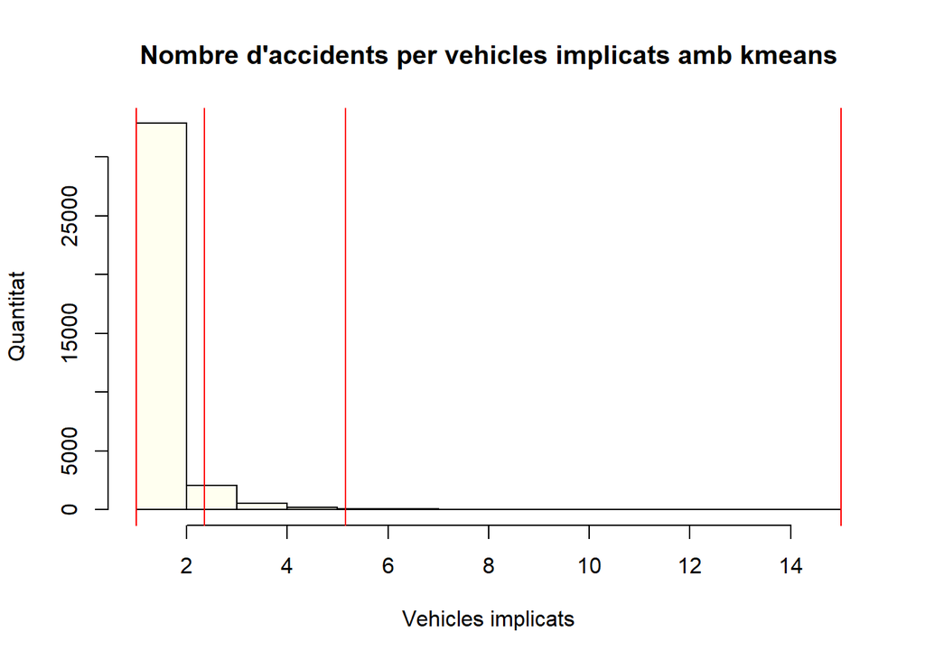

```r
hist(accidentData$VE_TOTAL, main="Nombre d'accidents per vehicles implicats amb kmeans",xlab="Vehicles implicats", ylab="Quantitat",col = "ivory")
abline(v=discretize(accidentData$VE_TOTAL, method="cluster", onlycuts=TRUE),col="red")
```

Podem observar que sense passar cap argument i que l’algorisme triï el conjunt de particions es mostren tres clústers que agrupen els vehicles implicats en les franges esmentades. Podem assignar el propi clúster com una variable més al dataset per treballar-hi després.

```r
accidentData$VE_TOTAL_KM<- (discretize(accidentData$VE_TOTAL, "cluster" ))
head(accidentData$VE_TOTAL_KM)
```

```
## [1] [1,1.5)    [2.73,15]  [1.5,2.73) [1,1.5)    [1,1.5)    [1.5,2.73)
## Levels: [1,1.5) [1.5,2.73) [2.73,15]
```

### 1.4.3 Normalització

Ara normalitzarem el nombre de morts pel màxim afegint un nou valor a les dades que contindrà el valor.

```r
accidentData$FATALS_NM<- (accidentData$FATALS/max(accidentData[,"FATALS"]))
head(accidentData$FATALS_NM)
```

```
## [1] 0.375 0.125 0.125 0.125 0.125 0.125
```

Suposem que ens cal normalitzar per la diferencia per ubicar entre 0 i 1 la variable del nombre de morts de l’accident donat que l’algorisme de mineria que utilitzarem així ho requereix. Observem la distribució de la variable original i les generades.

```r
accidentData$FATALS_ND = (accidentData$FATALS-min(accidentData$FATALS))/(max(accidentData$FATALS)-min(accidentData$FATALS))

max(accidentData$FATALS)
```

```
## [1] 8
```

```r
min(accidentData$FATALS)
```

```
## [1] 1
```

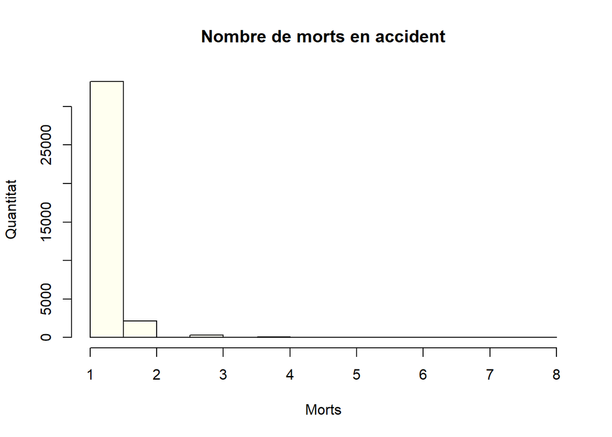

```r
hist(accidentData$FATALS,xlab="Morts", col="ivory",ylab="Quantitat", main="Nombre de morts en accident")
```

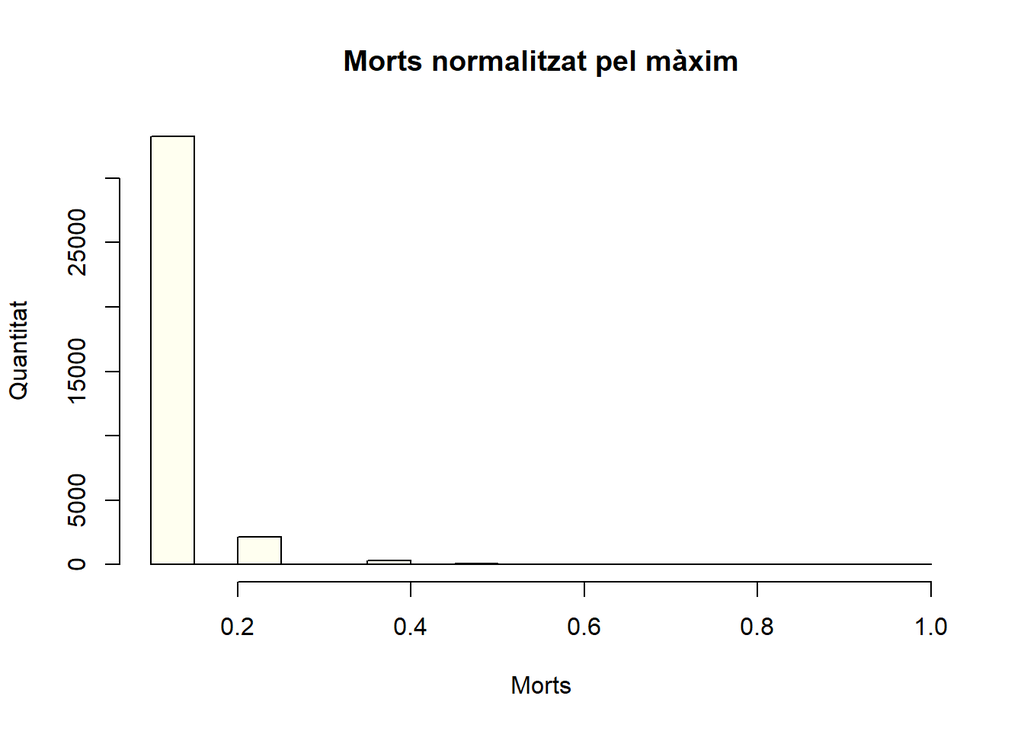

```r
hist(accidentData$FATALS_NM,xlab="Morts",ylab="Quantitat",col="ivory", main="Morts normalitzat pel màxim")
```

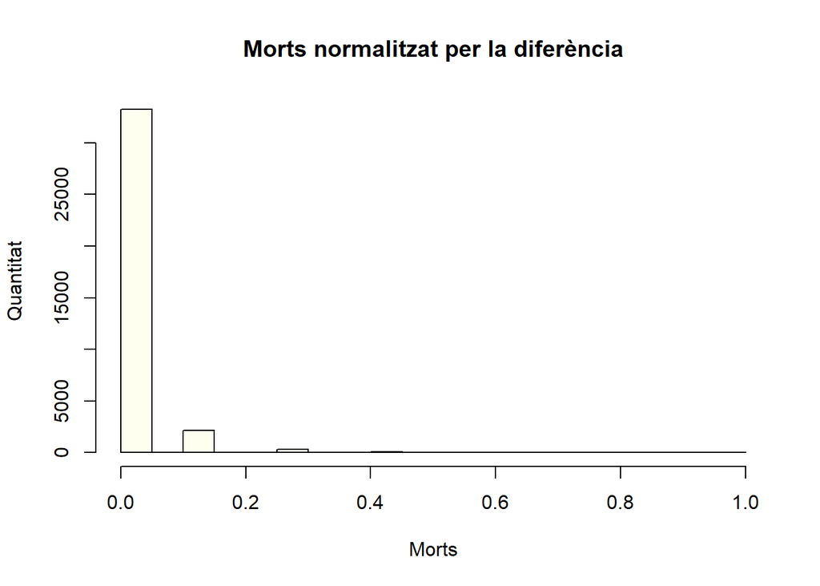

```r
hist(accidentData$FATALS_ND,xlab="Morts",ylab="Quantitat", col="ivory", main="Morts normalitzat per la diferència")
```

A continuació anem a normalitzar les altres columnes per assegurar-nos que cada variable contribueix per igual al nostre anàlisis.

```r
# Definim la funció de normalització
 nor <-function(x) { (x -min(x))/(max(x)-min(x))}
# Guardem un nou dataset normalitzat

accidentData$type<- NULL
n = c("FATALS","DRUNK_DR","VE_TOTAL","VE_FORMS","PVH_INVL","PEDS","PERSONS","PERMVIT","PERNOTMVIT")
accidentData<- accidentData %>% select(all_of(n))
accidentData_nor <- as.data.frame(lapply(accidentData, nor))

 head(accidentData_nor)
```

```
##      FATALS DRUNK_DR   VE_TOTAL   VE_FORMS PVH_INVL PEDS    PERSONS    PERMVIT
## 1 0.2857143     0.25 0.00000000 0.00000000        0    0 0.06557377 0.06557377
## 2 0.0000000     0.00 0.21428571 0.21428571        0    0 0.09836066 0.09836066
## 3 0.0000000     0.00 0.07142857 0.07142857        0    0 0.03278689 0.03278689
## 4 0.0000000     0.00 0.00000000 0.00000000        0    0 0.08196721 0.08196721
## 5 0.0000000     0.00 0.00000000 0.00000000        0    0 0.01639344 0.01639344
## 6 0.0000000     0.00 0.07142857 0.07142857        0    0 0.04918033 0.04918033
##   PERNOTMVIT
## 1          0
## 2          0
## 3          0
## 4          0
## 5          0
## 6          0
```

## 1.5 Procés de PCA

Tant l’ **anàlisi de components principals, principal component analysis (PCA) en anglès, com la descomposició de valors singulars, singular value decomposition (SVD)** en anglès, són tècniques que ens permeten treballar amb noves característiques anomenades components, que certament són independents entre si. En realitat, aquestes dues tècniques ens permeten representar el joc de dades en un nou sistema de coordenades que anomenem components principals. Aquest sistema està més ben adaptat a la distribució del joc de dades, de manera que recull millor la seva variabilitat.

Apliquem l’anàlisi de components principals al row data set per això comencem executant la funció **prcomp()**.

```r
pca.acc <- prcomp(accidentData_nor)
summary(pca.acc)
```

```
## Importance of components:
##                           PC1     PC2    PC3    PC4     PC5     PC6     PC7
## Standard deviation     0.1168 0.08755 0.0690 0.0484 0.03269 0.02437 0.01072
## Proportion of Variance 0.4520 0.25389 0.1577 0.0776 0.03539 0.01967 0.00381
## Cumulative Proportion  0.4520 0.70584 0.8635 0.9411 0.97652 0.99619 1.00000
##                              PC8       PC9
## Standard deviation     1.143e-14 2.491e-15
## Proportion of Variance 0.000e+00 0.000e+00
## Cumulative Proportion  1.000e+00 1.000e+00
```

Com es pot observar la funció summary, ens torna la proporció de variància aplicada al conjunt total de cada atribut. Gràcies a això, l’atribut 1 explica el 0.452 de variabilitat del total de dades; en canvi, l’atribut 7 explica només el 0.00381.

A continuació es mostra un histograma per veure el pes de cada atribut sobre el conjunt total de dades:

```r
if (!require('factoextra')) install.packages('factoextra'); library('factoextra')
#Els valors propis corresponen a la quantitat de variació explicada per cada component principal (PC).
ev= get_eig(pca.acc)
ev
```

```
##         eigenvalue variance.percent cumulative.variance.percent
## Dim.1 1.364366e-02     4.519469e+01                    45.19469
## Dim.2 7.664656e-03     2.538921e+01                    70.58391
## Dim.3 4.760727e-03     1.576993e+01                    86.35384
## Dim.4 2.342530e-03     7.759642e+00                    94.11348
## Dim.5 1.068327e-03     3.538839e+00                    97.65232
## Dim.6 5.937915e-04     1.966938e+00                    99.61926
## Dim.7 1.149407e-04     3.807416e-01                   100.00000
## Dim.8 1.305543e-28     4.324617e-25                   100.00000
## Dim.9 6.203717e-30     2.054984e-26                   100.00000
```

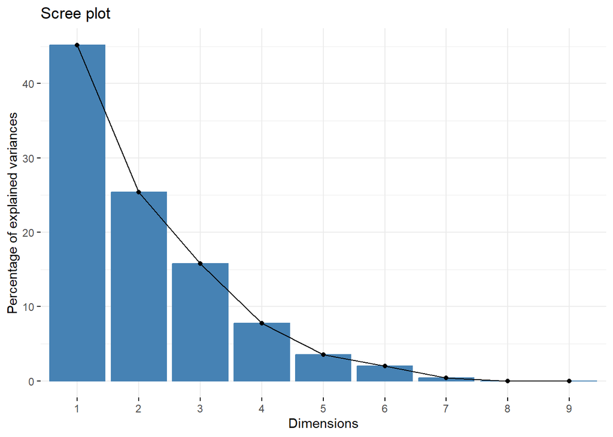

```r
fviz_eig(pca.acc)
```

En aquest exercici es va decidir utilitzar el mètode de Kàiser per decidir quina de les variables obtingudes seran escollides. Aquest criteri mantindrà totes aquelles variables la variància de les quals sigui superior a 1.

```r
# Calculem la variància dels components principals a partir de la desviació estàndard

var_acc <- pca.acc$sdev^2

var_acc
```

```
## [1] 1.364366e-02 7.664656e-03 4.760727e-03 2.342530e-03 1.068327e-03
## [6] 5.937915e-04 1.149407e-04 1.305543e-28 6.203717e-30
```

Amb els resultats obtinguts és molt complicat decidir quines són les components principals components a escollir. **Aquest fet podria estar causat per no haver escalat les dades prèviament.** Per tant, el següent pas és escalar les dades i tornar a calcular la variància per veure quines dades selecciones

```r
# Escalem les dades
acc_scale <- scale(accidentData_nor)
# Calculem les components principals
pca.acc_scale <- prcomp(acc_scale)
# Mostramos la varianza de dichas variables:
var_acc_scale <- pca.acc_scale$sdev^2
head(var_acc_scale)
```

```
## [1] 3.5632826 1.8581532 1.1186798 1.0185157 0.8423082 0.5603141
```

Després d’analitzar la variància i aplicant el criteri de Kàiser ens quedarem amb les components principals 1,2,3 i 4 que són les superiors a 1. Aquest criteri té el problema de sobreestimar el nombre de factors, però malgrat això és el que aplicarem per analitzar els resultats.

Mostrem l’histograma de percentatge de variància explicat amb les dades escalades:

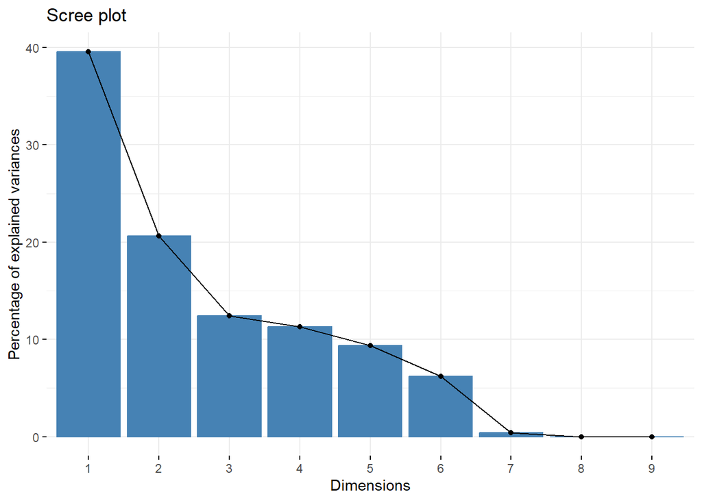

```r
fviz_eig(pca.acc_scale)
```

```r
ev = get_eig(pca.acc_scale)
ev
```

```
##         eigenvalue variance.percent cumulative.variance.percent
## Dim.1 3.563283e+00     3.959203e+01                    39.59203
## Dim.2 1.858153e+00     2.064615e+01                    60.23817
## Dim.3 1.118680e+00     1.242978e+01                    72.66795
## Dim.4 1.018516e+00     1.131684e+01                    83.98479
## Dim.5 8.423082e-01     9.358980e+00                    93.34377
## Dim.6 5.603141e-01     6.225712e+00                    99.56948
## Dim.7 3.874645e-02     4.305161e-01                   100.00000
## Dim.8 3.781577e-26     4.201752e-25                   100.00000
## Dim.9 2.016132e-26     2.240146e-25                   100.00000
```

Els valors propis es poden utilitzar per determinar el nombre de components principals a retenir després de la PCA (Kaiser 1961):

- Un valor propi > 1 indica que els PCs representen més variància de la que representa una de les variables originals de les dades estandarditzades. Això s’utilitza habitualment com a punt de tall per al qual es conserven els PCs. Això només és cert quan les dades estan estandarditzades.
- També podem limitar el nombre de components a aquest nombre que representa una determinada fracció de la variància total. Per exemple, si estem satisfets amb el 80% de la variància total explicada, fem servir el nombre de components per aconseguir-ho que són les 4 components principals vists abans.

Continuem amb l’anàlisi dels components principals. Després d’aplicar el mètode Kàiser s’han seleccionat els 4 components principals.

```r
var <- get_pca_var(pca.acc_scale)
var
```

```
## Principal Component Analysis Results for variables
##  ===================================================
##   Name       Description
## 1 "$coord"   "Coordinates for the variables"
## 2 "$cor"     "Correlations between variables and dimensions"
## 3 "$cos2"    "Cos2 for the variables"
## 4 "$contrib" "contributions of the variables"
```

Els components de get_pca_var() es poden utilitzar en el diagrama de variables de la següent manera:

- **var$coord**: coordenades de variables per crear un diagrama de dispersió.
- **var$cos2**: representa la qualitat de representació de les variables al mapa de factors. Es calcula com les coordenades al quadrat: var.cos2 = var.coord * var.coord.
- **var$contrib**: conté les contribucions (en percentatge) de les variables als components principals. La contribució d’una variable (var) a un determinat component principal és (en percentatge): (var.cos2 * 100) / (cos2 total del component).

```r
#Utilitzem els 4 components principals trobats abans
head(var$coord[,1:4],11)
```

```
##                  Dim.1       Dim.2       Dim.3       Dim.4
## FATALS     -0.30725642  0.07606945  0.28817514 -0.73967833
## DRUNK_DR   -0.04921565 -0.38170799 -0.26454706 -0.58497489
## VE_TOTAL   -0.83708697  0.28706095 -0.34390477  0.13727724
## VE_FORMS   -0.86483356  0.18416941 -0.02398033  0.21866655
## PVH_INVL   -0.06062570  0.30358100 -0.85844575 -0.18336810
## PEDS        0.48249027  0.82661079  0.13673775 -0.08353380
## PERSONS    -0.88514448  0.21755791  0.19732665 -0.07582156
## PERMVIT    -0.88736748  0.19749105  0.22352113 -0.06716534
## PERNOTMVIT  0.45872440  0.85355861  0.04773257 -0.10804664
```

### 1.5.1 Qualitat de representació

La qualitat de representació de les variables en el mapa de factors s’anomena cos2 (cosinus quadrat, coordenades quadrades). Podem accedir al cos2 de la següent manera:

```r
head(var$cos2[,1:4],11)
```

```
##                  Dim.1       Dim.2       Dim.3       Dim.4
## FATALS     0.094406509 0.005786562 0.083044911 0.547124037
## DRUNK_DR   0.002422180 0.145700988 0.069985146 0.342195618
## VE_TOTAL   0.700714591 0.082403990 0.118270488 0.018845040
## VE_FORMS   0.747937080 0.033918370 0.000575056 0.047815060
## PVH_INVL   0.003675475 0.092161422 0.736929104 0.033623861
## PEDS       0.232796860 0.683285394 0.018697211 0.006977896
## PERSONS    0.783480750 0.047331446 0.038937806 0.005748910
## PERMVIT    0.787421038 0.039002717 0.049961697 0.004511183
## PERNOTMVIT 0.210428078 0.728562294 0.002278398 0.011674076
```

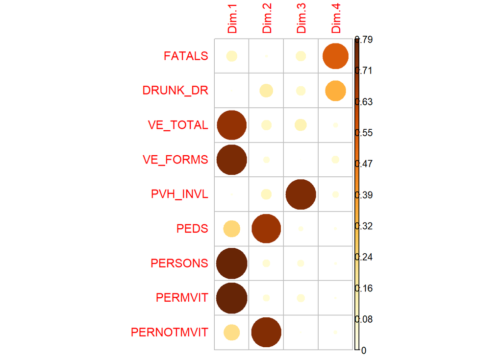

```r
corrplot(var$cos2[,1:4], is.corr=FALSE)
```

També és possible crear un diagrama de barres de variables cos2 mitjançant la funció fviz_cos2():

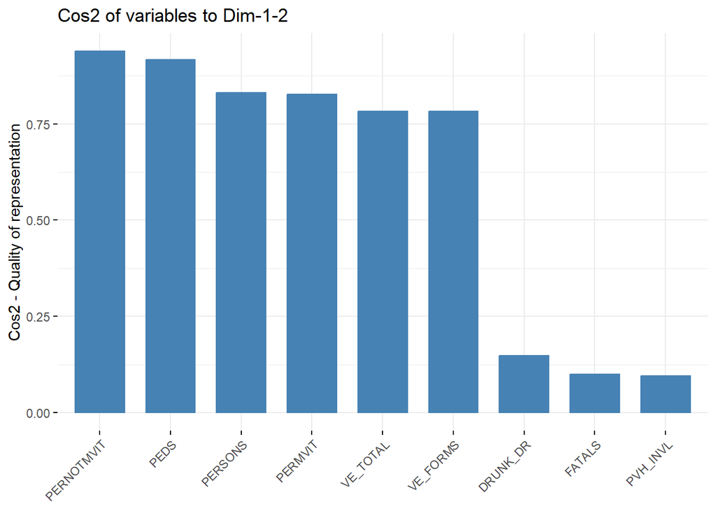

```r
fviz_cos2(pca.acc_scale, choice = "var", axes = 1:2)
```

- Un cos2 elevat indica una bona representació de la variable en el component principal. En aquest cas, la variable es col·loca prop de la circumferència del cercle de correlació.
- Un cos2 baix indica que la variable no està perfectament representada pels PC. En aquest cas, la variable està a prop del centre del cercle.

Per a una variable donada, la suma del cos2 de tots els components principals és igual a un.

Si una variable està perfectament representada per només dos components principals (Dim.1 i Dim.2), la suma del cos2 en aquests dos PCs és igual a un. En aquest cas les variables es col·locaran en el cercle de correlacions.

Per a algunes de les variables, poden ser necessaris més de 2 components per representar perfectament les dades. En aquest cas les variables es situen dins del cercle de correlacions.

En resum:

- Els valors de cos2 s’utilitzen per estimar la qualitat de la representació
- Com més propera estigui una variable al cercle de correlacions, millor serà la seva representació al mapa de factors (i més important és interpretar aquests components)
- Les variables que estan properes al centre de la trama són menys importants per als primers components.

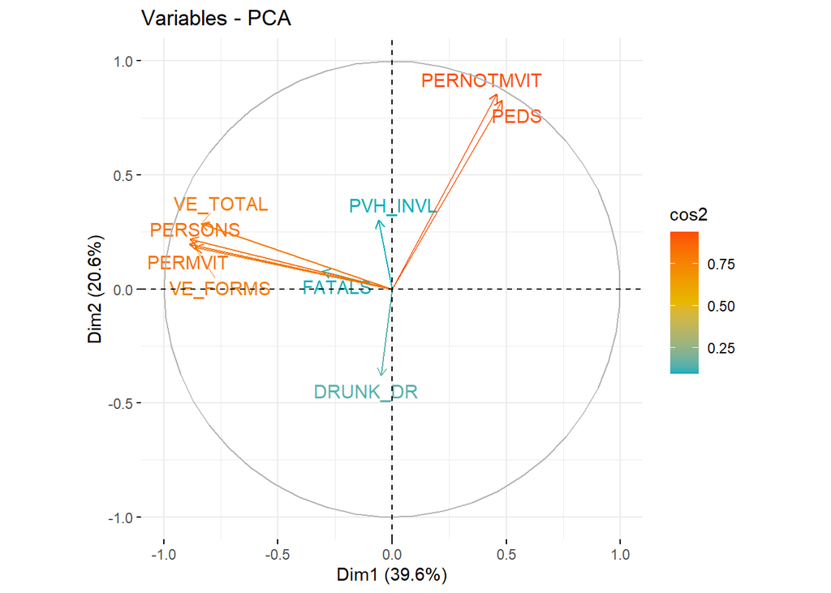

```r
fviz_pca_var(pca.acc_scale,
             col.var = "cos2",
             gradient.cols = c("#00AFBB", "#E7B800", "#FC4E07"),
             repel = TRUE
             )
```

### 1.5.2 Contribució

Les contribucions de les variables en la comptabilització de la variabilitat d’un determinat component principal s’expressen en percentatge.

Les variables que estan correlacionades amb PC1 (és a dir, Dim.1) i PC2 (és a dir, Dim.2) són les més importants per explicar la variabilitat en el conjunt de dades.

Les variables que no estan correlacionades amb cap PC o amb les darreres dimensions són variables amb una contribució baixa i es poden eliminar per simplificar l’anàlisi global.

La contribució de les variables es pot extreure de la següent manera:

```r
head(var$contrib[,1:4],11)
```

```
##                  Dim.1      Dim.2       Dim.3      Dim.4
## FATALS      2.64942527  0.3114147  7.42347448 53.7177824
## DRUNK_DR    0.06797608  7.8411720  6.25604798 33.5974816
## VE_TOTAL   19.66486180  4.4347254 10.57232696  1.8502454
## VE_FORMS   20.99011424  1.8253807  0.05140488  4.6945826
## PVH_INVL    0.10314857  4.9598398 65.87489045  3.3012610
## PEDS        6.53321358 36.7722855  1.67136397  0.6851044
## PERSONS    21.98761218  2.5472306  3.48069265  0.5644400
## PERMVIT    22.09819245  2.0990044  4.46613018  0.4429174
## PERNOTMVIT  5.90545583 39.2089469  0.20366845  1.1461852
```

Quan més gran sigui el valor de la contribució, més aportació de la variable hi haurà al component.

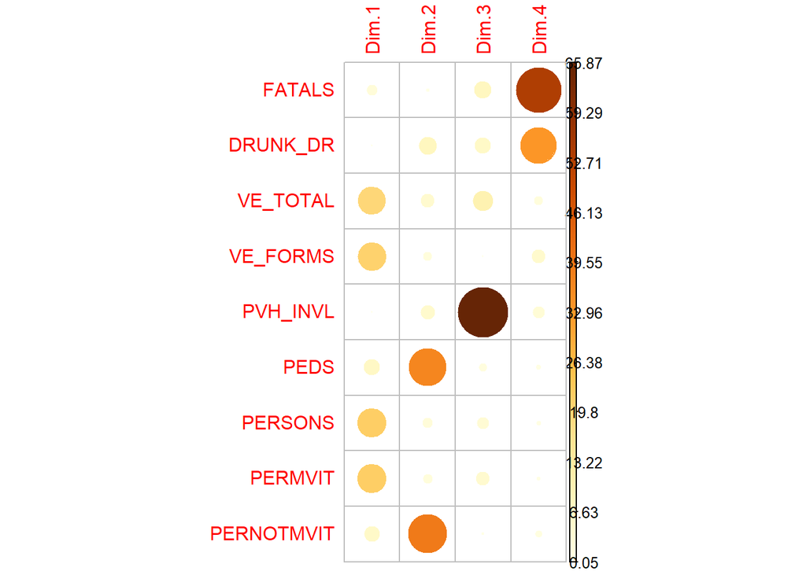

```r
corrplot(var$contrib[,1:4], is.corr=FALSE)
```

Les variables més importants (que més contribueixen) es poden ressaltar a la gràfica de correlació de la següent manera:

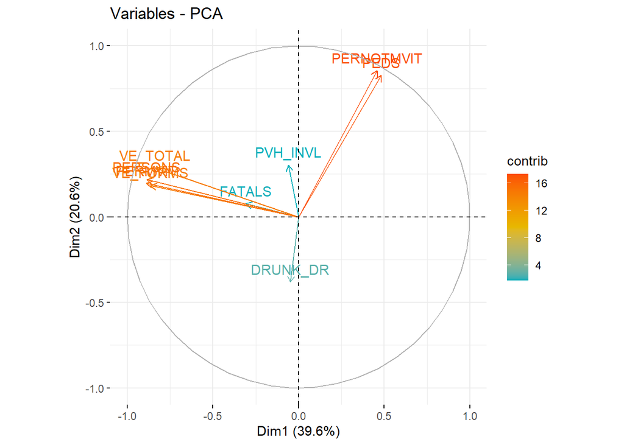

```r
fviz_pca_var(pca.acc_scale, col.var = "contrib",
             gradient.cols = c("#00AFBB", "#E7B800", "#FC4E07")
             )
```

S’ observa que la variable que més aporta a les components principals són **PEDS i PERNOTMVIT per un costat i VE_TOTAL, VE_FORMS, PERSONS i PERMVIT**. Això és degut al fet que estan correlacionades. En concret pel diagrama de correlació d’ abans que PEDS esta molt bé correlacionada amb PERNOTMVIT. D’ altra banda VE_TOTAL, VE_FORMS, PERSONS i PERMVIT estan també força correlacionades. La correlació de FATALS amb aquest grup de variables no és elevada però apunta en la mateixa direcció.

Podrien ara refer els components excloent les variables que no aporten informació. Un cop refet aquestes noves variables substitueixen a les originals que les formen i es podrien utilitzar per exemple com un indicador de gravetat d’accident ja que inclou vehicle en moviment, aturat, vianants, conductors i d’altres implicats en una sola variable.